# Evaluating Measurement and Structural Invariance via Multi-Group CFA

Tommaso Feraco

## Today in the workflow

Specify → Identify → **Estimate → Evaluate → Revise/Report**

Today we focus on:

- **Evaluate**: “Does the *same* measurement model hold across groups?”
- **Report**: “What level of invariance supports which claims?”

In particular:

- Why measurement invariance is a *prerequisite* for group comparisons
- The MG-CFA ladder (configural → metric → scalar → strict)
- How to evaluate invariance (Δ fit + local diagnostics)
- Partial invariance: what to free, how to justify it
- (Briefly) structural invariance: variances/covariances/means

## Learning objectives

By the end of this lesson you can:

- Explain **configural / metric / scalar / strict** invariance in plain language
- Fit MG-CFA models in `lavaan` using `group.equal`
- Compare nested models using **ΔCFI / ΔRMSEA / Δχ²** (and know the limits)
- Use **score tests / modification indices** to diagnose non-invariance
- Implement **partial invariance** via `group.partial`
- State which inferences are valid under each invariance level

## A hot topic

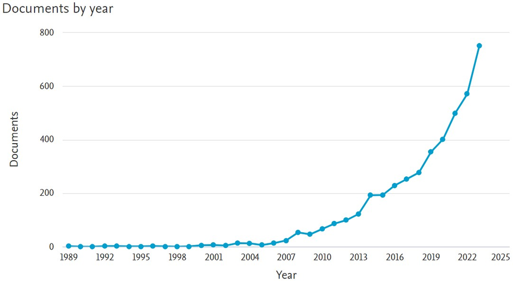

## Introduction

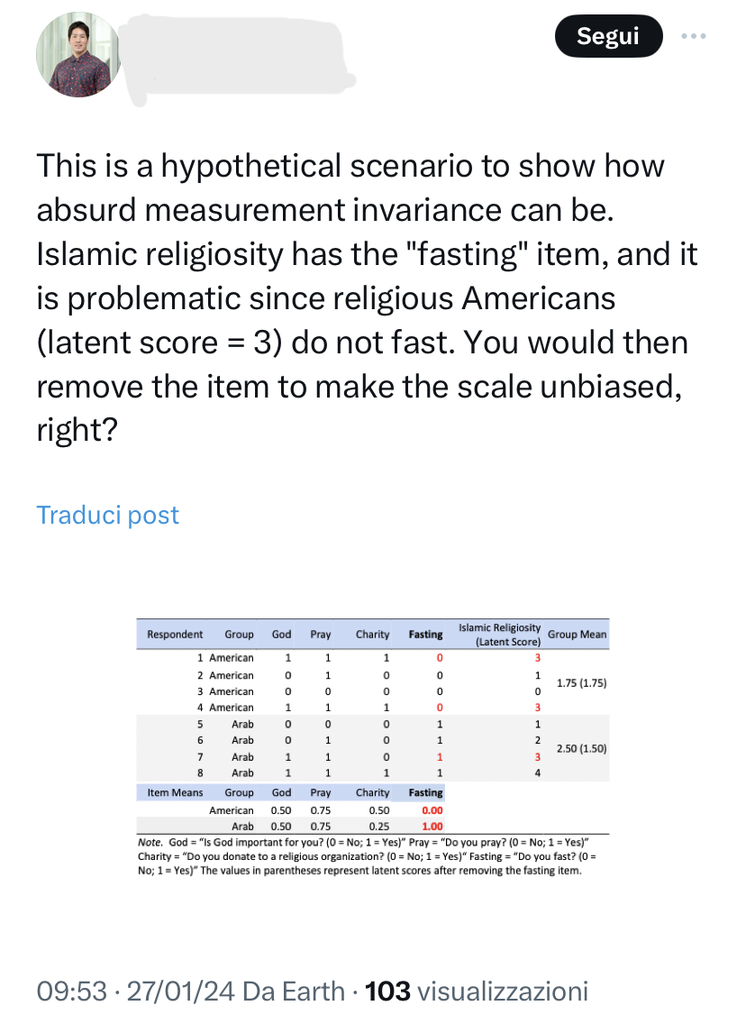

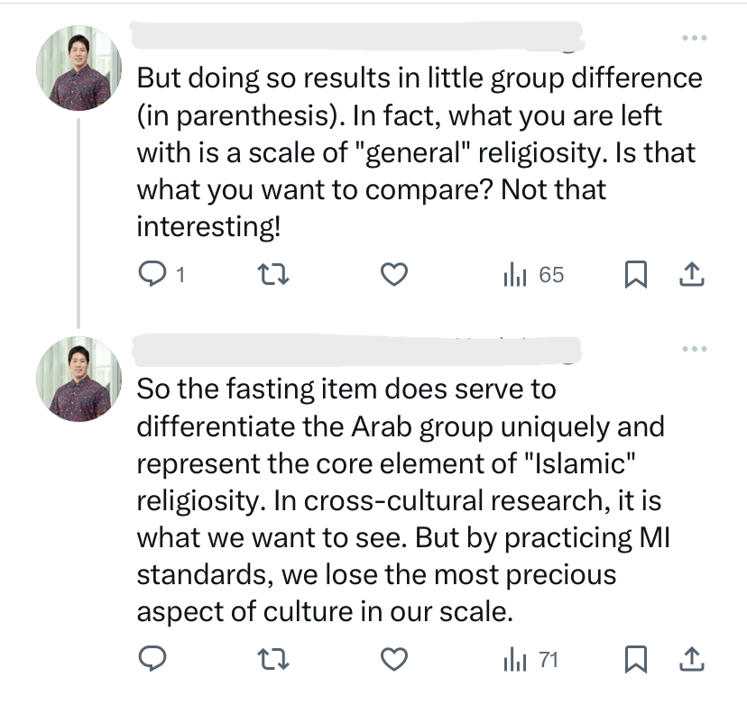

## The importance of Measurement Invariance

- Researchers often compare groups on psychological constructs, assuming instruments measure the *same* latent variables across groups.
- This assumption is often untested.
- **Measurement invariance is a prerequisite** for meaningful comparisons across groups (and across time).

[figure not shown]

## Invariance of a Structural Equation Model

More generally, testing invariance evaluates to what extent a hypothesized SEM can be considered **invariant** (same parameters) across groups.

Invariance is commonly used for comparisons across:

- gender
- age groups
- clinical vs non-clinical
- culture / language / nationality
- time (longitudinal invariance)

## Assessing invariance: the multi-group analysis

- Multi-group analysis is the most widely used method to assess invariance.
- In this lesson we focus on **CFA models** (MG-CFA).
- Logic: estimate the same model in multiple groups, then add equality constraints and check what breaks.

## The starting point (MG-CFA)

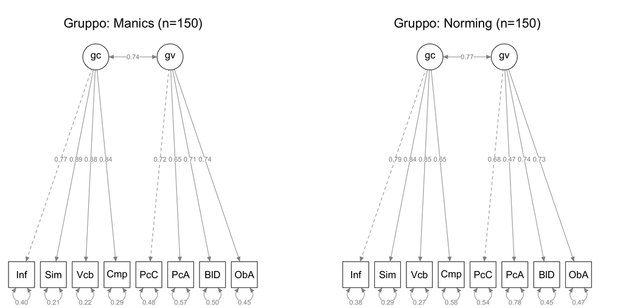

## The idea (constraints ladder)

1. Start with the same model in all groups (baseline: all structural parameters are *free* to vary across groups)
2. Add constraints (more restrictive models: loadings, intercepts, residual variances, … *fixed* to be equal)
3. Compare fit: does the constraint produce a meaningful worsening?

## Invariance steps (measurement)

1. **Configural**: same factor structure (same “form”)
2. **Metric / weak**: equal loadings ($Λ$)
3. **Scalar / strong**: equal intercepts ($τ$)
4. **Strict**: equal residual variances ($Θ$)

> **Scalar invariance** (full or partial) is the gateway to **latent mean** comparisons.

## What level do you need for which claim?

| Claim / Comparison | Minimum invariance |
| --- | --- |
| Same factor structure (same “form”) | Configural |
| Compare relations (regressions/correlations) | Metric (often) |
| Compare latent means | Scalar (often partial scalar) |
| Compare observed means directly | Not recommended without invariance evidence |

## Step-by-step guide (summary)

| Step | Model | Constrain | Compare to |
| --- | --- | --- | --- |
| 0 | Separate CFAs | — | — |
| 1 | Configural | — | — |
| 2 | Metric | loadings | configural |
| 3 | Scalar | loadings + intercepts | metric |
| 4 | Strict | + residual variances | scalar |
| 5–7 | Structural invariance | lv variances/covariances/means | previous |

## MG-CFA scheme (steps 1–4)

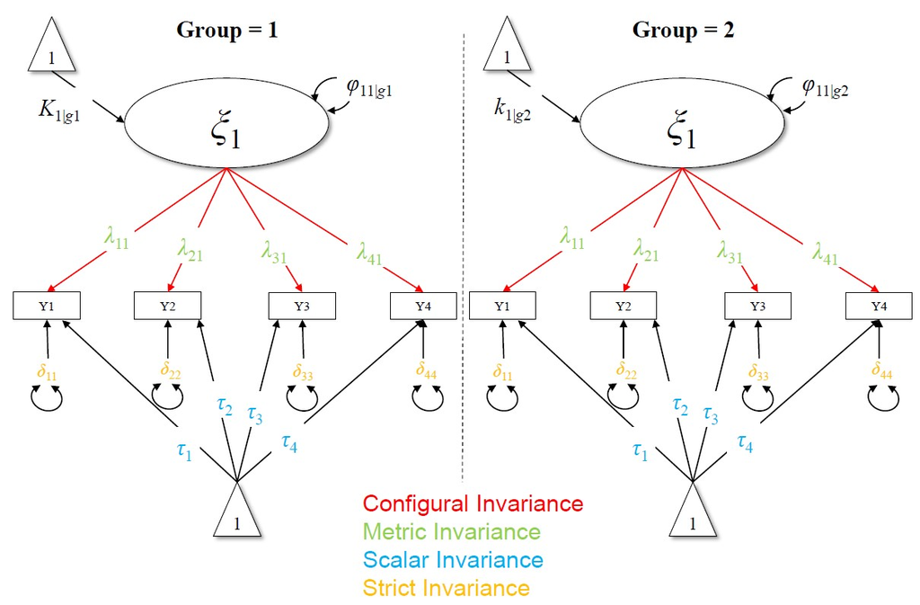

Slide stolen from Psicostat’s meeting by [Enrico Perinelli](https://psicostat.dpss.psy.unipd.it/meetings/psicostat33.html).

## TO READ

All the next ‘non-invariance’ slides are inspired in large part from the following [blog post](https://www.the100.ci/2024/01/10/a-casual-but-causal-take-on-measurement-invariance/?fbclid=IwAR2kcAPkq0i1IZXntLkcbeSoU1D-Pb_R45VBhJ4EOZUmY_Cv3T0ne6-KbNE)

## Step 0: Separate models for each group

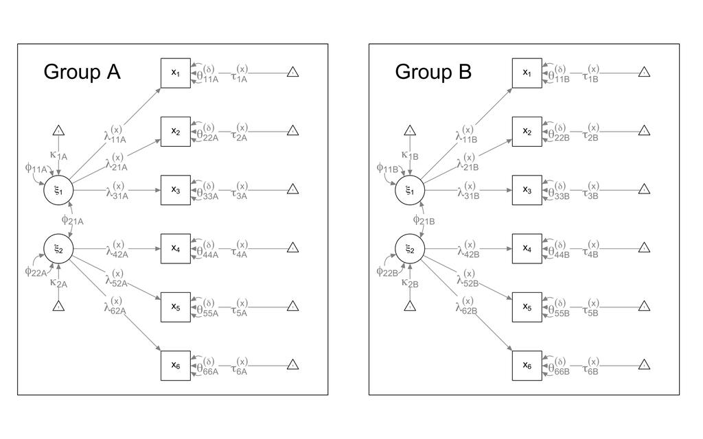

## Step 1: Configural invariance

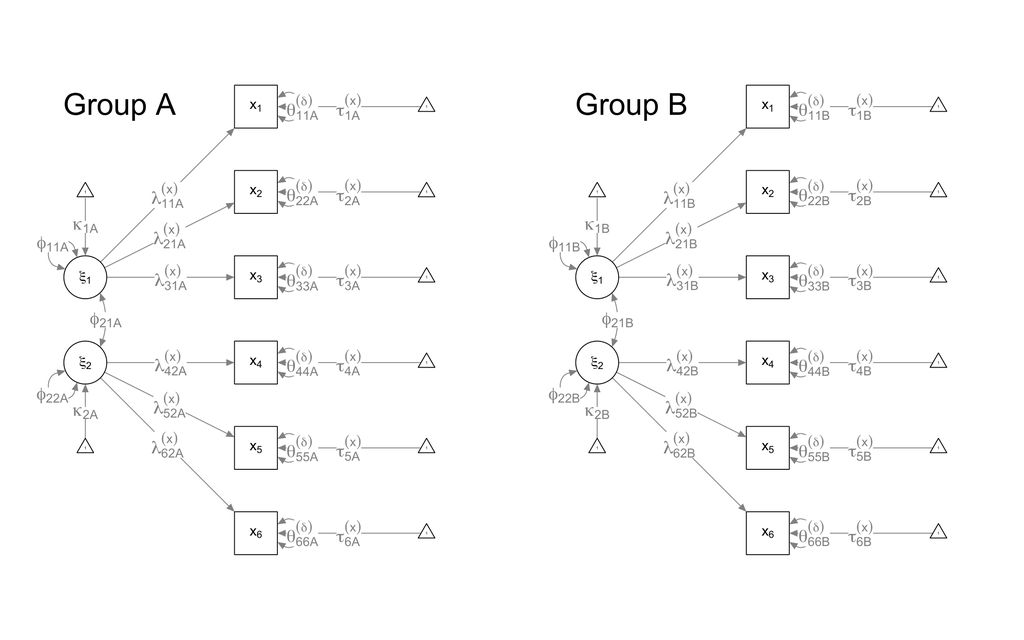

## Step 1: Configural (non-)invariance

Configural invariance means that the “form” of the models is the same in the groups of interest. Form entails both the number of latent variables and whether the loadings are non-zero to begin with.

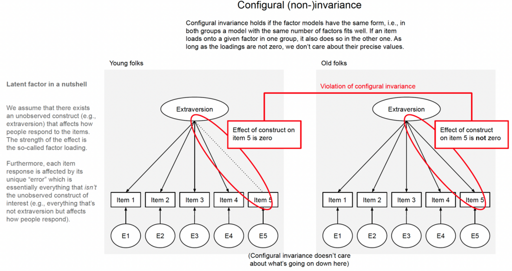

## Step 2: Metric invariance

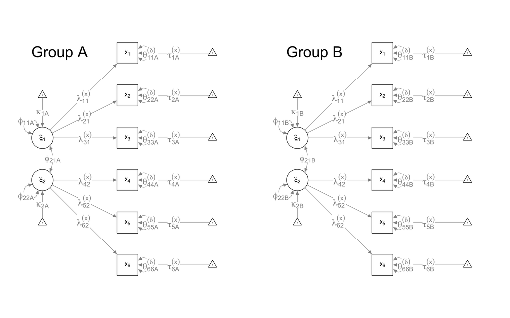

## Step 2: Metric (non-)invariance

Metric invariance means that for each item, the loading of the factor on the item is the same in the two groups (or, more precisely, that we cannot reject the hypothesis that the loadings are the same).

[figure not shown]

## Step 2: Metric (non-)invariance

The source of group differences does not come from the latent variable!

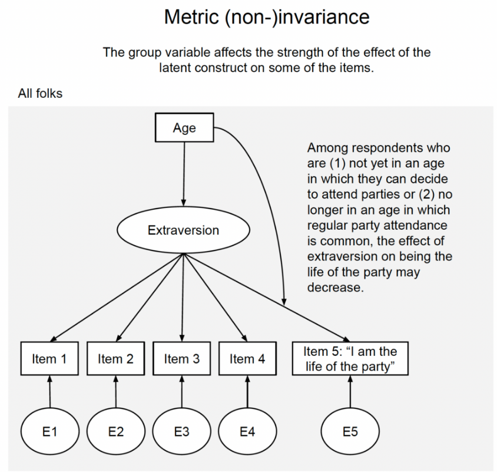

## Step 3: Scalar invariance

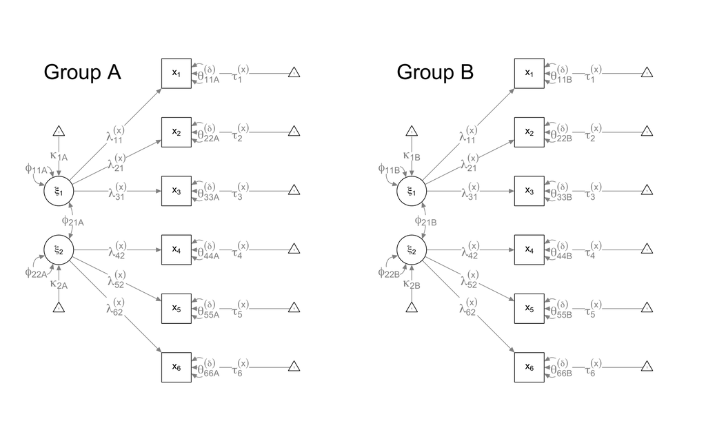

## Step 3: Scalar invariance

Scalar invariance means that for each item, the intercept is the same. This means that group differences in the item responses are fully accounted for by group differences in the latent construct.

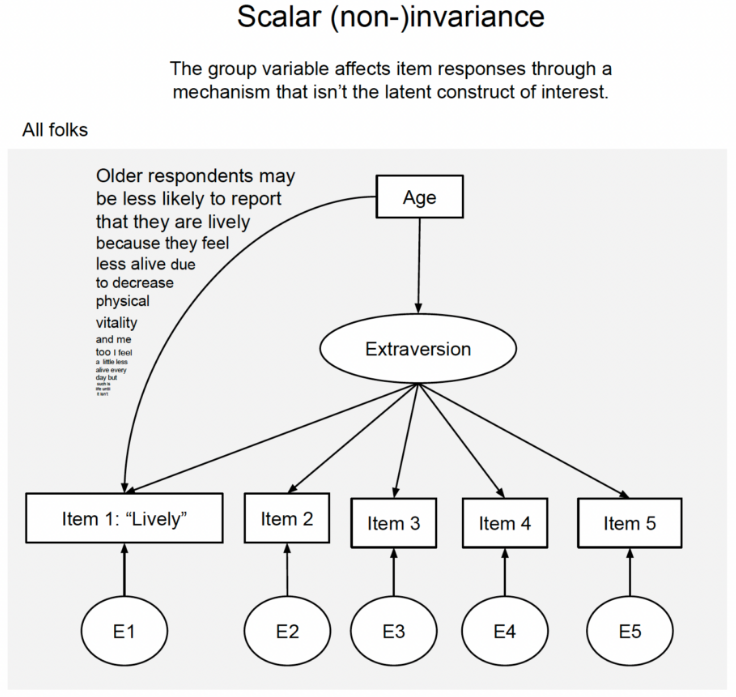

## Step 4: Invariance of observed residual variances

Residual invariance means that for each item, the residual variance—the variance of the ominous E pointing into the items—is the same. We can again phrase this statistically: if we regressed the item scores on the factor, then the variance of the remaining residual would be the same in the groups (i.e., there would be homoscedasticity).

## Step 4: Invariance of observed residual variances

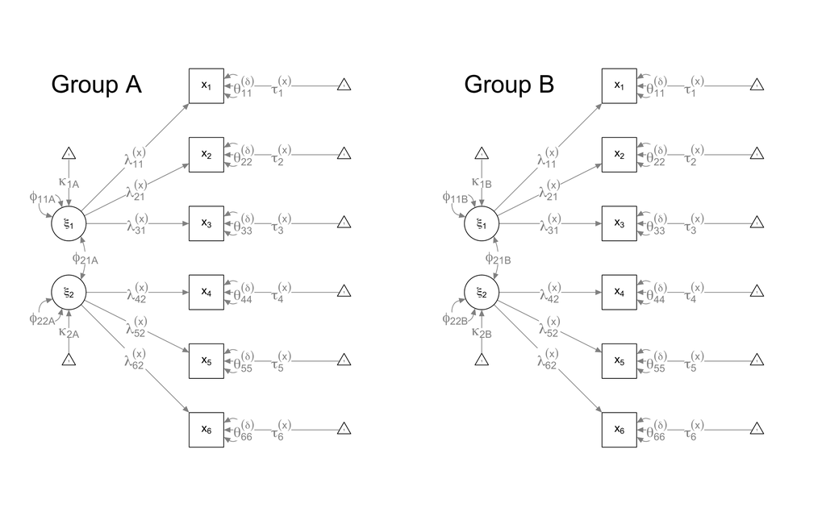

The thing about the residual is that it captures everything that’s not explained in the model, and explaining changes in the amount of unexplained things seems a bit futile. Residual invariance is often not tested because it’s not necessary for latent mean comparisons. It’s a bit of an anticlimactic level to end on.

## Step 5: Invariance of latent variances

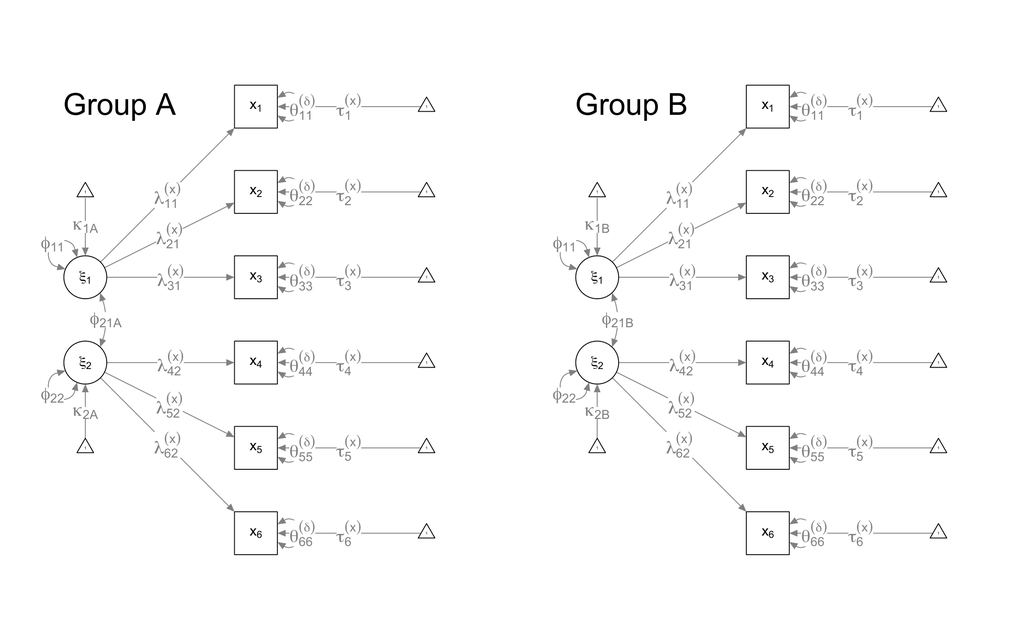

## Step 6: Invariance of latent covariances

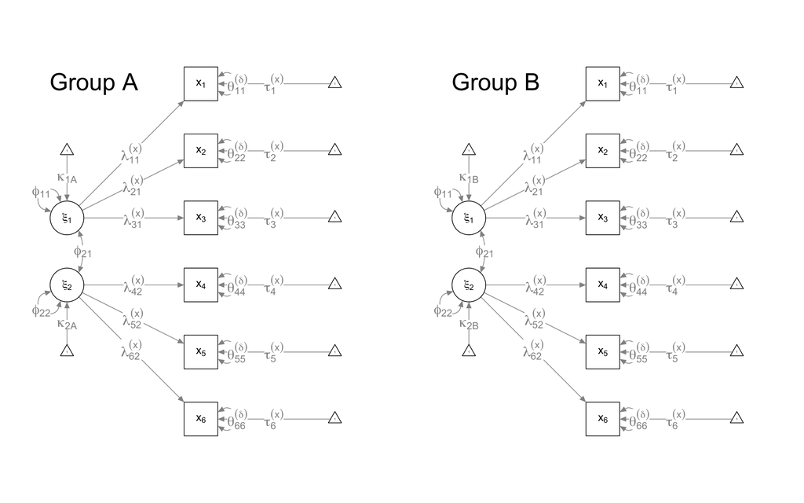

## Step 7: Invariance of latent means

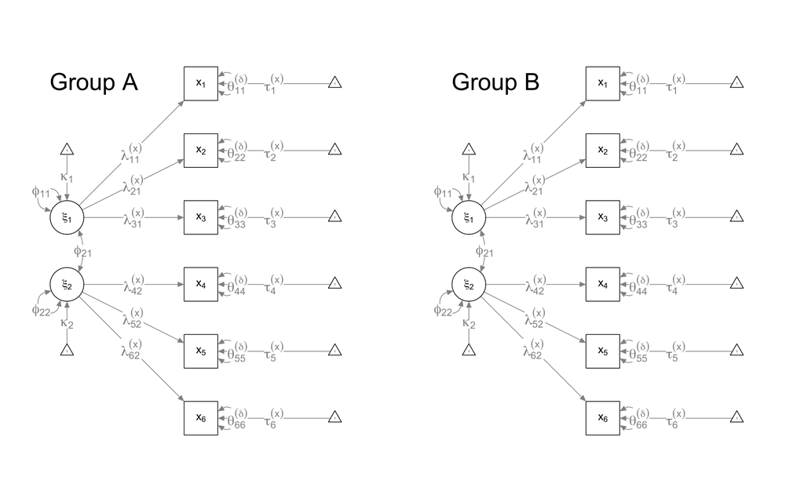

## Evaluation: global comparison

Common ingredients:

- Model fit in the more constrained model (χ², RMSEA, CFI/TLI, SRMR)
- **Change in fit** vs less constrained model:
  - Δχ² (highly N-sensitive)
  - ΔCFI (often used)
  - ΔRMSEA / ΔSRMR (sometimes used)
  - ΔBIC (information criteria)

A marked worsening of fit indices indicates that the considered invariance model is too restrictive and thus must be rejected.

**Warning**

make a comprehensive evaluation based on different fit indices, rather than on a single fit criterion.

## Practical comparison rules

Let MOD-A be a reference model and MOD-B a more restrictive model.

- Δχ² = χ²(B) − χ²(A) (N-sensitive; use with caution)
- ΔCFI = CFI(B) − CFI(A)
  - heuristic: accept if ΔCFI > −.01
- ΔBIC = BIC(B) − BIC(A)
  - negative values favor B

**Warning**

**Pitfall:** with robust estimators (e.g., MLR/WLSMV), the χ² difference test is not always the plain `anova()` test.

## Partial invariance (what it is)

When invariance is untenable at some level (metric/scalar/strict), you can allow **some** parameters to differ:

- Free non-invariant loadings/intercepts/residual variances
- Keep most constraints to preserve comparability

Options (in practice):

1. Free a small number of parameters (theory-driven)
2. Argue differences are negligible (rarely convincing)
3. Remove problematic indicators (last resort)
4. Conclude constructs are not comparable *with the current instrument* or *theoretically* (sometimes correct!)

## How do we choose what to free?

- Inspect parameters by group (largest differences)
- Inspect **score tests / modification indices** for constrained parameters
- Free **one at a time** and re-evaluate
- Always justify based on theory and measurement logic

**Warning**

**Pitfall:** “MI shopping” can overfit noise. Partial invariance must remain *interpretable*.

# In R — a small MG-CFA example

## CFA model (toy)

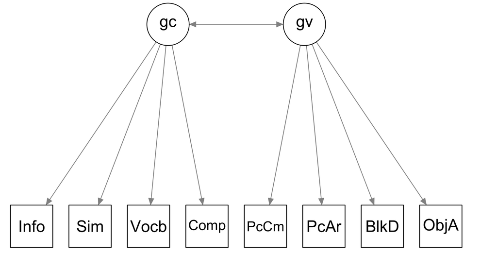

## Step 0 — Separate models (sanity check)

This is **not** configural invariance. It’s only: “Does the model work in each group?”

```r
m0 <- cfa(m, data = d[d$Group == 0, ])
m1 <- cfa(m, data = d[d$Group == 1, ])

fitMeasures(m0, fi)
```

```
     cfi      tli     srmr    rmsea      bic      aic
   1.000    1.021    0.034    0.000 5214.258 5162.428
```

```r
fitMeasures(m1, fi)
```

```
     cfi      tli     srmr    rmsea      bic      aic
   0.945    0.910    0.040    0.050 7899.949 7841.867
```

## Step 1 — Configural invariance

```r
m_all <- cfa(m, data = d)
fitMeasures(m_all, fi)
```

```
      cfi       tli      srmr     rmsea       bic       aic
    1.000     1.007     0.021     0.000 13070.106 13004.430
```

```r
m_conf <- cfa(m, data = d, group = "Group")
fitMeasures(m_conf, fi)
```

```
      cfi       tli      srmr     rmsea       bic       aic
    0.976     0.961     0.034     0.035 13224.946 13032.295
```

## Step 2 — Metric invariance (equal loadings)

```r
m_metr <- cfa(m, data = d, group = "Group",
             group.equal = "loadings")

fitMeasures(m_metr, fi)
```

```
      cfi       tli      srmr     rmsea       bic       aic
    0.976     0.967     0.038     0.032 13198.034 13027.276
```

```r
# Compare to configural
anova(m_metr, m_conf)
```

```
Chi-Squared Difference Test

       Df   AIC   BIC  Chisq Chisq diff RMSEA Df diff Pr(>Chisq)
m_conf 26 13032 13225 35.392
m_metr 31 13027 13198 40.373     4.9804     0       5     0.4183
```

```r
fitMeasures(m_metr, "cfi") - fitMeasures(m_conf, "cfi")
```

```
cfi
  0
```

```r
fitMeasures(m_metr, "bic") - fitMeasures(m_conf, "bic")
```

```
    bic
-26.912
```

## Step 2 diagnostics (what breaks?)

```r
# Score tests for equality constraints
lavTestScore(m_metr)$uni |> head(10)
```

```
univariate score tests:

   lhs op   rhs    X2 df p.value
1 .p2. == .p28. 2.336  1   0.126
2 .p3. == .p29. 0.310  1   0.578
3 .p4. == .p30. 0.877  1   0.349
4 .p6. == .p32. 1.798  1   0.180
5 .p7. == .p33. 0.227  1   0.634
```

```r
# Parameter table (useful for mapping constraint ids)
parameterTable(m_metr)[1:15, c("lhs","op","rhs","group","free","ustart")]
```

```
   lhs op rhs group free ustart
1   f1 =~  x1     1    0      1
2   f1 =~  x2     1    1     NA
3   f1 =~  x3     1    2     NA
4   f1 =~  x4     1    3     NA
5   f2 =~  x5     1    0      1
6   f2 =~  x6     1    4     NA
7   f2 =~  x7     1    5     NA
8   x1 ~~  x1     1    6     NA
9   x2 ~~  x2     1    7     NA
10  x3 ~~  x3     1    8     NA
11  x4 ~~  x4     1    9     NA
12  x5 ~~  x5     1   10     NA
13  x6 ~~  x6     1   11     NA
14  x7 ~~  x7     1   12     NA
15  f1 ~~  f1     1   13     NA
```

## Step 3 — Scalar invariance (loadings + intercepts)

```r
m_scal <- cfa(m, data = d, group = "Group",
             group.equal = c("loadings","intercepts"))

fitMeasures(m_scal, fi)
```

```
      cfi       tli      srmr     rmsea       bic       aic
    0.984     0.981     0.039     0.024 13168.052 13019.185
```

```r
anova(m_scal, m_metr)
```

```
Chi-Squared Difference Test

       Df   AIC   BIC  Chisq Chisq diff RMSEA Df diff Pr(>Chisq)
m_metr 31 13027 13198 40.373
m_scal 36 13019 13168 42.283     1.9096     0       5     0.8615
```

```r
fitMeasures(m_scal, "cfi") - fitMeasures(m_metr, "cfi")
```

```
  cfi
0.008
```

## What can we fix?

Through the option `group.equal` , it is possible to constrain groups of parameters to be equal across groups in order to assess increasingly restrictive invariance hypotheses:

| Constrained parameters | In R |
| --- | --- |
| Factor loadings | `loadings` |
| Intercepts of manifest variables | `intercepts` |
| Residual variances of manifest variables | `residuals` |
| Residual covariances of manifest variables | `residual.covariances` |
| Residual variances of latent variables | `lv.variances` |
| Residual covariances of latent variable | `lv.covariances` |
| Intercepts/means of latent variables | `means` |
| All regression coefficients | `regressions` |
| Thresholds | `thresholds` |

## Partial invariance in lavaan

`group.partial` allows selected parameters to differ.

```r
m_metr_p <- cfa(m, data = d, group = "Group",
               group.equal = "loadings",
               group.partial = "f2 =~ x5")

fitMeasures(m_metr_p, fi)
```

```
      cfi       tli      srmr     rmsea       bic       aic
    0.976     0.967     0.038     0.032 13198.034 13027.276
```

> Which model should we compare this to, and why? How to we interpret the results of such a model?

## Common mistakes (invariance)

- Comparing **latent means** without (partial) **scalar invariance**
- Freeing many parameters without theoretical rationale (“MI fishing”)
- Ignoring identification choices (scaling, reference indicators, factor means)
- Using automated helpers as a black box

# Case study

## The case study dataset

(Beaujean et al., 2012)

```r
load("../data/dmg.RData")
str(dmg)
```

```
'data.frame':   300 obs. of  10 variables:
 $ id       : int  1 2 3 4 5 6 7 8 9 10 ...
 $ diagnosis: Factor w/ 2 levels "manic","norming": 1 1 1 1 1 1 1 1 1 1 ...
 $ Info     : num  8.95 11.94 5.8 14.69 6 ...
 $ Sim      : num  9.34 9.93 6.64 17.72 6.56 ...
 $ Vocab    : num  12.39 4.57 6.03 13.21 7.83 ...
 $ Comp     : num  11.61 8.86 5.03 13.38 5.77 ...
 $ PicComp  : num  11.15 4.95 8.02 11.54 8.84 ...
 $ PicArr   : num  15.7 5.46 7.65 12.06 5.39 ...
 $ BlkDsgn  : num  11.45 3.43 9.28 10.46 7.39 ...
 $ ObjAsmb  : num  15.54 3.8 8.63 14.38 9.92 ...
```

**Important**

SEM work with variance-covariance matrices. For this reason, it is sufficient to find it in the original articles to use their “data”! The data we will use have been generated based on the parameters provided in the article, modifying the sample size.

## Model

```r
model <- "
gc =~ Info + Sim + Vocab + Comp
gv =~ PicComp + PicArr + BlkDsgn + ObjAsmb
"
```

## Step 0 — Separate models

```r
m_man <- cfa(model, data = dmg[dmg$diagnosis == "manic", ])
m_nor <- cfa(model, data = dmg[dmg$diagnosis == "norming", ])

fitMeasures(m_man, c("chisq","df","rmsea","cfi","tli"))
```

```
 chisq     df  rmsea    cfi    tli
54.052 19.000  0.111  0.949  0.924
```

```r
fitMeasures(m_nor, c("chisq","df","rmsea","cfi","tli"))
```

```
 chisq     df  rmsea    cfi    tli
18.151 19.000  0.000  1.000  1.003
```

## Step 1 — Configural

```r
m_conf2 <- cfa(model, data = dmg, group = "diagnosis")
fitMeasures(m_conf2, c("chisq","df","rmsea","cfi","tli"))
```

```
 chisq     df  rmsea    cfi    tli
72.203 38.000  0.077  0.971  0.957
```

`ANY COMMENTS?`

## Step 2 — Metric

```r
m_metr2 <- cfa(model, data = dmg, group = "diagnosis",
              group.equal = "loadings")

fitMeasures(m_metr2, c("chisq","df","rmsea","cfi","tli"))
```

```
 chisq     df  rmsea    cfi    tli
88.153 44.000  0.082  0.963  0.952
```

## Step 2 — Metric

```r
anova(m_metr2, m_conf2)
```

```
Chi-Squared Difference Test

        Df   AIC   BIC  Chisq Chisq diff   RMSEA Df diff Pr(>Chisq)
m_conf2 38 11239 11424 72.203
m_metr2 44 11243 11406 88.153      15.95 0.10515       6    0.01402 *
---
Signif. codes:  0 '***' 0.001 '**' 0.01 '*' 0.05 '.' 0.1 ' ' 1
```

```r
fitMeasures(m_metr2, "cfi") - fitMeasures(m_conf2, "cfi")
```

```
   cfi
-0.008
```

```r
fitMeasures(m_metr2, "bic") - fitMeasures(m_conf2, "bic")
```

```
    bic
-18.272
```

## Step 3 — Scalar and partial scalar

```r
m_scal2 <- cfa(model, data = dmg, group = "diagnosis",
              group.equal = c("loadings","intercepts"))

fitMeasures(m_scal2, c("chisq","df","rmsea","cfi","tli"))
```

```
  chisq      df   rmsea     cfi     tli
144.667  50.000   0.112   0.920   0.910
```

`COMMENTS`

## Step 3 — Scalar and partial scalar

```r
anova(m_scal2, m_metr2)
```

```
Chi-Squared Difference Test

        Df   AIC   BIC   Chisq Chisq diff   RMSEA Df diff Pr(>Chisq)
m_metr2 44 11243 11406  88.153
m_scal2 50 11287 11428 144.667     56.513 0.23691       6  2.292e-10 ***
---
Signif. codes:  0 '***' 0.001 '**' 0.01 '*' 0.05 '.' 0.1 ' ' 1
```

```r
fitMeasures(m_scal2, "cfi") - fitMeasures(m_metr2, "cfi")
```

```
   cfi
-0.043
```

## Step 3 — Inspection of equality constraints

```r
# Identify the worst constraints
lavTestScore(m_scal2)$uni |> head(10)
```

```
univariate score tests:

     lhs op   rhs     X2 df p.value
1   .p2. == .p31.  0.419  1   0.517
2   .p3. == .p32.  0.335  1   0.563
3   .p4. == .p33.  2.389  1   0.122
4   .p6. == .p35.  7.026  1   0.008
5   .p7. == .p36.  0.072  1   0.789
6   .p8. == .p37.  0.000  1   0.988
7  .p20. == .p49.  8.342  1   0.004
8  .p21. == .p50. 42.173  1   0.000
9  .p22. == .p51.  2.691  1   0.101
10 .p23. == .p52. 11.089  1   0.001
```

```r
ptscal <- parameterTable(m_scal2); ptscal[ptscal$op == "~1",-1]
```

```
       lhs op rhs user block group free ustart exo label plabel start    est
20    Info ~1        0     1     1   18     NA   0 .p20.  .p20. 10.09 10.385
21     Sim ~1        0     1     1   19     NA   0 .p21.  .p21. 12.07 11.497
22   Vocab ~1        0     1     1   20     NA   0 .p22.  .p22. 10.25 10.352
23    Comp ~1        0     1     1   21     NA   0 .p23.  .p23.  9.96 10.185
24 PicComp ~1        0     1     1   22     NA   0 .p24.  .p24. 10.90 10.803
25  PicArr ~1        0     1     1   23     NA   0 .p25.  .p25. 11.24 10.916
26 BlkDsgn ~1        0     1     1   24     NA   0 .p26.  .p26. 10.30 10.416
27 ObjAsmb ~1        0     1     1   25     NA   0 .p27.  .p27. 10.44 10.608
28      gc ~1        0     1     1    0      0   0        .p28.  0.00  0.000
29      gv ~1        0     1     1    0      0   0        .p29.  0.00  0.000
49    Info ~1        0     2     2   43     NA   0 .p20.  .p49. 10.10 10.385
50     Sim ~1        0     2     2   44     NA   0 .p21.  .p50. 10.30 11.497
51   Vocab ~1        0     2     2   45     NA   0 .p22.  .p51.  9.80 10.352
52    Comp ~1        0     2     2   46     NA   0 .p23.  .p52. 10.10 10.185
```

[output cut: 27 more lines]

## Step 3 — Partial scalar invariance

```r
# Example: free the intercept of Sim
m_scal2_p <- cfa(model, data = dmg, group = "diagnosis",
                group.equal = c("loadings","intercepts"),
                group.partial = "Sim ~ 1")
fitMeasures(m_scal2_p, c("chisq","df","rmsea","cfi","tli"))
```

```
  chisq      df   rmsea     cfi     tli
100.174  49.000   0.083   0.957   0.950
```

```r
anova(m_scal2_p, m_metr2)
```

```
Chi-Squared Difference Test

          Df   AIC   BIC   Chisq Chisq diff    RMSEA Df diff Pr(>Chisq)
m_metr2   44 11243 11406  88.153
m_scal2_p 49 11245 11389 100.174     12.021 0.096752       5     0.0345 *
---
Signif. codes:  0 '***' 0.001 '**' 0.01 '*' 0.05 '.' 0.1 ' ' 1
```

```r
fitMeasures(m_scal2_p, "cfi") - fitMeasures(m_metr2, "cfi")
```

```
   cfi
-0.006
```

## What does partial scalar mean (interpretation)?

- Most intercepts are comparable across groups
- A small subset is not (e.g., `Sim`)
- Latent mean comparisons can be *more defensible* under partial scalar, but interpret non-invariant indicators substantively

> Which item behaves differently across groups, and what could it reflect?

A causal interpretation of invariance (Rohrer & Paulewicz, 2025)

## Invariance of Residuals of observed variables(1)

```r
# Note: parameter "Sim~1" remains free
m.rvo=cfa(model,dmg,group="diagnosis",
          group.equal=c("loadings","intercepts","residuals"),
          group.partial="Sim~1") #Note that this is still here
# Inspection of fit indices
fitMeasures(m.rvo,c("chisq","df","rmsea","cfi","nnfi"))
```

```
  chisq      df   rmsea     cfi    nnfi
127.344  57.000   0.091   0.940   0.941
```

## Invariance of Residuals of observed variables (2)

```r
anova(m.rvo,m_scal2_p) # Note: Comparison model Partial Scalar invariance
```

```
Chi-Squared Difference Test

          Df   AIC   BIC  Chisq Chisq diff   RMSEA Df diff Pr(>Chisq)
m_scal2_p 49 11245 11389 100.17
m.rvo     57 11256 11371 127.34     27.169 0.12639       8  0.0006609 ***
---
Signif. codes:  0 '***' 0.001 '**' 0.01 '*' 0.05 '.' 0.1 ' ' 1
```

```r
fitMeasures(m.rvo,"cfi")-fitMeasures(m_scal2_p,"cfi")
```

```
   cfi
-0.016
```

```r
fitMeasures(m.rvo,"bic")-fitMeasures(m_scal2_p,"bic")
```

```
    bic
-18.461
```

```r
# The Invariance of Residuals of observed variables
#   is not satisfactory. Let's take a look at equality constraints
```

## Inspection of equality constraints

```r
lavTestScore(m.rvo)$uni |> head(10)
```

```
univariate score tests:

     lhs op   rhs     X2 df p.value
1   .p2. == .p31.  4.802  1   0.028
2   .p3. == .p32.  1.156  1   0.282
3   .p4. == .p33.  0.138  1   0.710
4   .p6. == .p35.  7.948  1   0.005
5   .p7. == .p36.  0.099  1   0.753
6   .p8. == .p37.  0.020  1   0.888
7   .p9. == .p38.  0.107  1   0.744
8  .p10. == .p39.  0.108  1   0.743
9  .p11. == .p40.  0.504  1   0.478
10 .p12. == .p41. 12.169  1   0.000
```

```r
# (... see complete output )
# From a first analysis, we can see that
#  the residuals of variables  “Comp” and “PicComp”
#  have Modification indices that are
#  particularly high, so let's free them
```

## Invariance of Residuals of observed variables (1)

```r
m.rvo.P=cfa(model,dmg,group="diagnosis",
            group.equal=c("loadings","intercepts","residuals"),
            group.partial=c("Sim~1","PicComp~~PicComp","Comp~~Comp"))
# Fit indices
fitMeasures(m.rvo.P,c("chisq","df","rmsea","cfi","nnfi"))
```

```
  chisq      df   rmsea     cfi    nnfi
102.420  55.000   0.076   0.960   0.959
```

## Partial Invariance of Residuals of observed variables (2)

```r
# Evaluation of Partial Invariance of Residuals of observed variables
anova(m.rvo.P,m_scal2_p) # Note: Comparison model Partial Scalar invariance
```

```
Chi-Squared Difference Test

          Df   AIC   BIC  Chisq Chisq diff RMSEA Df diff Pr(>Chisq)
m_scal2_p 49 11245 11389 100.17
m.rvo.P   55 11235 11357 102.42     2.2458     0       6     0.8958
```

```r
fitMeasures(m.rvo.P,"cfi")-fitMeasures(m_scal2_p,"cfi")
```

```
  cfi
0.003
```

```r
fitMeasures(m.rvo.P,"bic")-fitMeasures(m_scal2_p,"bic")
```

```
    bic
-31.977
```

```r
# Paartial Invariance of Residuals of observed variables is satisfactory.
# Question: What can we say about overall
# Measurement Invariance of the baseline theoretical model?
```

## Invariance of Variance of latent variables (1)

```r
m.vvl=cfa(model,dmg,group="diagnosis",
          group.equal=c("loadings","intercepts","residuals",
                        "lv.variances"),
          group.partial=c("Sim~1","PicComp~~PicComp","Comp~~Comp"))
# Fit indices
fitMeasures(m.vvl,c("chisq","df","rmsea","cfi","nnfi"))
```

```
  chisq      df   rmsea     cfi    nnfi
105.825  57.000   0.076   0.959   0.959
```

## Invariance of Variance of latent variables (2)

```r
anova(m.vvl,m.rvo.P)
```

```
Chi-Squared Difference Test

        Df   AIC   BIC  Chisq Chisq diff    RMSEA Df diff Pr(>Chisq)
m.rvo.P 55 11235 11357 102.42
m.vvl   57 11234 11349 105.83     3.4056 0.068449       2     0.1822
```

```r
fitMeasures(m.vvl,"cfi")-fitMeasures(m.rvo.P,"cfi")
```

```
   cfi
-0.001
```

```r
fitMeasures(m.vvl,"bic")-fitMeasures(m.rvo.P,"bic")
```

```
   bic
-8.002
```

```r
# OK, this looks good!
```

## Invariance of Covariance of latent variables (1)

```r
m.cvl=cfa(model,dmg,group="diagnosis",
          group.equal=c("loadings","intercepts"
                        ,"residuals","lv.variances","lv.covariances"),
          group.partial=c("Sim~1","PicComp~~PicComp","Comp~~Comp"))
# Fit indices
fitMeasures(m.cvl,c("chisq","df","rmsea","cfi","nnfi"))
```

```
  chisq      df   rmsea     cfi    nnfi
106.412  58.000   0.075   0.959   0.960
```

## Invariance of Covariance of latent variables(2)

```r
anova(m.cvl,m.vvl)
```

```
Chi-Squared Difference Test

      Df   AIC   BIC  Chisq Chisq diff RMSEA Df diff Pr(>Chisq)
m.vvl 57 11234 11349 105.83
m.cvl 58 11233 11344 106.41    0.58642     0       1     0.4438
```

```r
fitMeasures(m.cvl,"cfi")-fitMeasures(m.vvl,"cfi")
```

```
cfi
  0
```

```r
fitMeasures(m.cvl,"bic")-fitMeasures(m.vvl,"bic")
```

```
   bic
-5.117
```

```r
# OK, we're almost there!
```

## Invariance of Means of latent variables (1)

```r
# last step
m.med=cfa(model,dmg,group="diagnosis",
          group.equal=c("loadings","intercepts"
                        ,"residuals","lv.variances","lv.covariances",
                        "means"),
          group.partial=c("Sim~1","PicComp~~PicComp","Comp~~Comp"))
# Fit indices
fitMeasures(m.med,c("chisq","df","rmsea","cfi","nnfi"))
```

```
  chisq      df   rmsea     cfi    nnfi
110.933  60.000   0.075   0.957   0.960
```

## Invariance of Means of latent variables (2)

```r
anova(m.med,m.cvl)
```

```
Chi-Squared Difference Test

      Df   AIC   BIC  Chisq Chisq diff    RMSEA Df diff Pr(>Chisq)
m.cvl 58 11233 11344 106.41
m.med 60 11234 11337 110.93     4.5212 0.091673       2     0.1043
```

```r
fitMeasures(m.med,"cfi")-fitMeasures(m.cvl,"cfi")
```

```
   cfi
-0.002
```

```r
fitMeasures(m.med,"bic")-fitMeasures(m.cvl,"bic")
```

```
   bic
-6.886
```

```r
# This last model is also satisfactory
# ANY COMMENTS?
```

## Summing up

| Models | npar | df | chisq | cfi | tli | nnfi | agfi | srmr | rmsea | bic | aic |
| --- | --- | --- | --- | --- | --- | --- | --- | --- | --- | --- | --- |
| Manics | 17 | 19 | 54.05 | 0.95 | 0.92 | 0.92 | 0.84 | 0.05 | 0.11 | 5590.65 | 5539.47 |
| Norming | 17 | 19 | 18.15 | 1 | 1 | 1 | 0.94 | 0.03 | 0 | 5718.64 | 5667.46 |
| Configural | 50 | 38 | 72.2 | 0.97 | 0.96 | 0.96 | 0.98 | 0.04 | 0.08 | 11424.11 | 11238.93 |
| Metric | 44 | 44 | 88.15 | 0.96 | 0.95 | 0.95 | 0.98 | 0.06 | 0.08 | 11405.84 | 11242.88 |
| Scalar | 38 | 50 | 144.67 | 0.92 | 0.91 | 0.91 | 0.97 | 0.08 | 0.11 | 11428.13 | 11287.39 |
| Scalar Partial | 39 | 49 | 100.17 | 0.96 | 0.95 | 0.95 | 0.98 | 0.07 | 0.08 | 11389.34 | 11244.9 |
| Residual Variances | 31 | 57 | 127.34 | 0.94 | 0.94 | 0.94 | 0.98 | 0.08 | 0.09 | 11370.88 | 11256.07 |
| Residual Variances Partial | 33 | 55 | 102.42 | 0.96 | 0.96 | 0.96 | 0.98 | 0.07 | 0.08 | 11357.37 | 11235.14 |
| Latent Variances | 31 | 57 | 105.83 | 0.96 | 0.96 | 0.96 | 0.98 | 0.09 | 0.08 | 11349.36 | 11234.55 |
| Latent Covariances | 30 | 58 | 106.41 | 0.96 | 0.96 | 0.96 | 0.98 | 0.09 | 0.07 | 11344.25 | 11233.13 |
| Latent Means | 28 | 60 | 110.93 | 0.96 | 0.96 | 0.96 | 0.98 | 0.09 | 0.08 | 11337.36 | 11233.66 |

## Structural invariance

Test of multigroup invariance can also be used to compare differences in the regression coefficients of two or more groups (interactions).

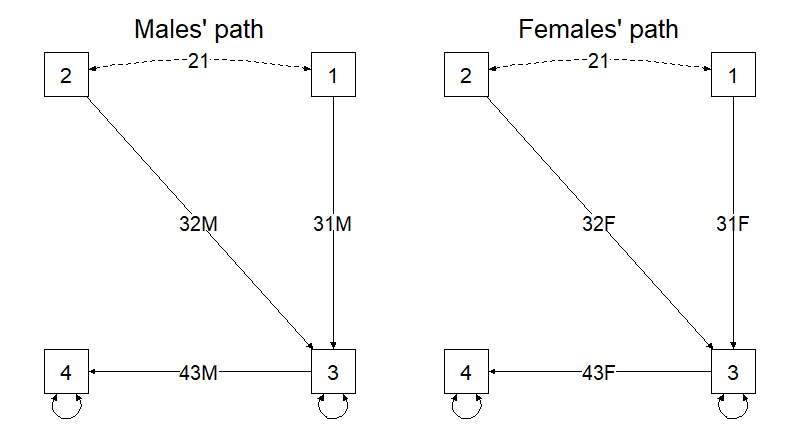

## Exercise

**Try it (15–25 min)**  
1. Fit configural, metric, scalar on the toy dataset `d`.  
2. Decide whether scalar is acceptable using ΔCFI + theory.  
3. If scalar fails, free **one** intercept using `group.partial`.  
4. Write 3–4 sentences: *what is comparable now, and what is not?*

../labs/Lab 07 — Invariance (MG-CFA) [link](https://feracotommaso.github.io/SEM-phd-course/labs/lab07_invariance_mgcfa.html)

## Take-home: 3 things

1. Invariance is about **comparability**
2. **Scalar (full/partial)** is the key for latent mean comparisons.
3. Partial invariance is legitimate, but must be **disciplined + theory-driven**.

## Further reading (extras)

- [Rohrer’s blogpost:](https://www.the100.ci/2024/01/10/a-casual-but-causal-take-on-measurement-invariance/?fbclid=IwAR2kcAPkq0i1IZXntLkcbeSoU1D-Pb_R45VBhJ4EOZUmY_Cv3T0ne6-KbNE) A casual but causal take on measurement invariance
- Partial invariance strategies and interpretability
- (Maassen et al., 2025): How much is invariance disregarded?
- lavaan tutorial: https://lavaan.ugent.be/tutorial/groups.html
- And controversies that I don’t like (Funder & Gardiner, 2024) (Robitzsch & Lüdtke, 2023)

## Acknowledgments

Thanks to Gianmarco Altoé for his slides!

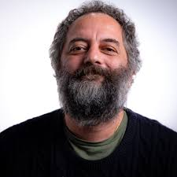

## References

Beaujean, A. A., Freeman, M. J., Youngstrom, E., & Carlson, G. (2012). The structure of cognitive abilities in youths with manic symptoms: a factorial invariance study. *Assessment*, *19*(4), 462–471. https://doi.org/10.1177/1073191111399037

Funder, D. C., & Gardiner, G. (2024). MIsgivings about measurement invariance. *European Journal of Personality*, *38*(6), 889–895. https://doi.org/10.1177/08902070241228338

Maassen, E., D’Urso, E. D., Assen, M. A. L. M. van, Nuijten, M. B., De Roover, K., & Wicherts, J. M. (2025). The dire disregard of measurement invariance testing in psychological science. *Psychological Methods*, *30*(5), 966–979. https://doi.org/10.1037/met0000624

Robitzsch, A., & Lüdtke, O. (2023). Why full, partial, or approximate measurement invariance are not a prerequisite for meaningful and valid group comparisons. *Structural Equation Modeling: A Multidisciplinary Journal*, *30*(6), 859–870. https://doi.org/10.1080/10705511.2023.2191292

Rohrer, J. M., & Paulewicz, B. (2025). Rethinking measurement invariance causally. *Current Research in Ecological and Social Psychology*, *9*, 100241. https://doi.org/10.1016/j.cresp.2025.100241

[figure not shown]